# Анализ цен сигарет в США

Arsentii Ivasiuk

November 11, 2018

## Введение

Датасет, который используется был взят на https://www.wiley.com/legacy/wileychi/baltagi/. Сопутствующая информация к датасету была взята на https://vincentarelbundock.github.io/Rdatasets/doc/plm/Cigar.html.

```r
cigar <- read.csv("Cigar.csv")
head(cigar)
```

```
##   X state year price  pop pop16  cpi  ndi sales pimin
## 1 1     1   63  28.6 3383  2236 30.6 1558  93.9  26.1
## 2 2     1   64  29.8 3431  2277 31.0 1684  95.4  27.5
## 3 3     1   65  29.8 3486  2328 31.5 1810  98.5  28.9
## 4 4     1   66  31.5 3524  2370 32.4 1915  96.4  29.5
## 5 5     1   67  31.6 3533  2394 33.4 2024  95.5  29.6
## 6 6     1   68  35.6 3522  2405 34.8 2202  88.4  32.0
```

Датасет состоит из 1380 наблюдений, которые были собраны с 1963 по 1992 год в штатах Америки. Наблюдения также включают цену за пачку сигарет (price), население штата (pop), население штата старше 16 лет (pop16), потребительский индекс для каждого года (cpi), доход на душу населения (ndi), количество проданых сигарет на душу населения (sales), минамальная цена за пачку сигарет в соседних штатах (pimin).

## Гипотезы

Мы заинтеросованы в том, чтобы проверить есть ли статистически значимые различия в цене сигарет в наблюдаемый период с помощью однопробного теста Стьюдента:
$$t = \frac{\overline{x} - mu_0}{s/\sqrt{n}}.$$
А также проверить есть ли какая-небудь зависимость между ценой пачки сигарет и средним доходом на душу населения с помощью корреляционного теста Пирсона.

## Анализ

```r
# descriptive analysis
cigar %>% select(-c(X, pimin)) %>%
  group_by(state) %>%
  summarise(ObservedYears = n(),
            MeanSales = mean(sales),
            SalesMin = min(sales),
            SalesMax = max(sales),
            Year_of_min = year[which.min(sales)],
            Year_of_max = year[which.max(sales)])
```

```
## # A tibble: 46 x 7
##    state ObservedYears MeanSales SalesMin SalesMax Year_of_min Year_of_max
##    <int>         <int>     <dbl>    <dbl>    <dbl>       <int>       <int>
##  1     1            30      107.     88.4     123.          68          80
##  2     3            30      113.     79       133.          92          74
##  3     4            30      115.     98.9     132.          66          80
##  4     5            30      115.     67.5     142           92          63
##  5     7            30      118.     83.6     156.          92          63
##  6     8            30      151.    119.      176.          91          69
##  7     9            30      164.     82.2     296.          91          66
##  8    10            30      126.     95.9     139           92          80
##  9    11            30      119.    104.      134           65          80
## 10    13            30      105.     78.4     126.          89          72
## # ... with 36 more rows
```

Теперь найдем средние цены на сигареты для каждого года. Потом для 30 значений средних проведем однопробный тест Стьюдента (t-test).

```r
cigar2 <- cigar %>%
  group_by(year) %>%
  summarise(MeanPrice = mean(price))
# t-test
t.test(cigar2$MeanPrice, mu = 0, conf.level = 0.99)
```

```
##
##  One Sample t-test
##
## data:  cigar2$MeanPrice
## t = 9, df = 30, p-value = 8e-10
## alternative hypothesis: true mean is not equal to 0
## 99 percent confidence interval:
##  47.5 89.9
## sample estimates:
## mean of x
##      68.7
```

А теперь построим соответствующий график.

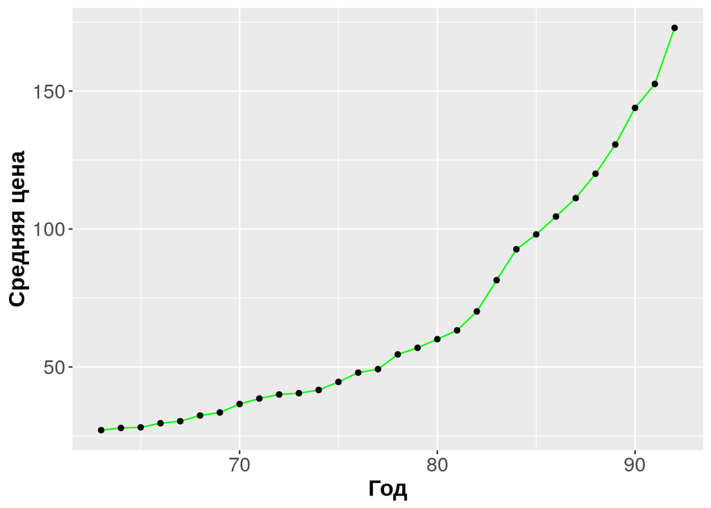

```r
ggplot(cigar2, aes(year, MeanPrice)) +
  geom_line(color = "green") +
  geom_point() +
  xlab("Год") +
  ylab("Средняя цена") +
    theme(axis.text.x = element_text(size = 14),
        axis.text.y = element_text(size = 14),
        legend.text = element_text(size = 14),
        axis.title = element_text(face = "bold", size = 16))
```

Теперь проведем корелляционный тест Пирсона для цен и среднего дохода на душу населения.

```r
cor.test(cigar$price, cigar$ndi)
```

```
##
##  Pearson's product-moment correlation
##
## data:  cigar$price and cigar$ndi
## t = 100, df = 1000, p-value <2e-16
## alternative hypothesis: true correlation is not equal to 0
## 95 percent confidence interval:
##  0.938 0.950
## sample estimates:
##   cor
## 0.944
```

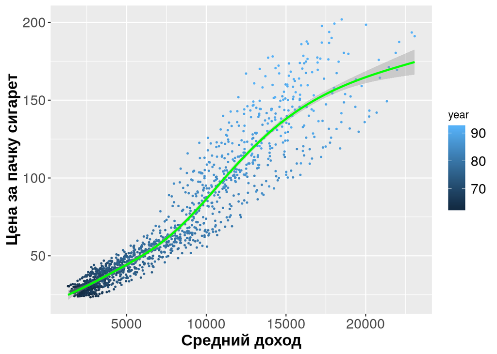

```r
ggplot(cigar, aes(ndi, price, color = year)) +
  geom_point(size = 0.5) +
  geom_smooth(color = "green", size = 1) +
  xlab("Средний доход") +
  ylab("Цена за пачку сигарет") +
  theme(axis.text.x = element_text(size = 14),
        axis.text.y = element_text(size = 14),
        legend.text = element_text(size = 14),
        axis.title = element_text(face = "bold", size = 16))
```

Теперь нужно посмотреть как меняются соотношения дохода на душу населения к цене за пачку сигарет (ndi / price) на выбраном промежутке времени

```r
cigar3 <- cigar %>%
    group_by(year) %>%
    summarise(MeanNDI_over_Price = mean(ndi)/mean(price))
t.test(cigar3$MeanNDI_over_Price, mu = 0, conf.level = 0.99)
```

```
##
##  One Sample t-test
##
## data:  cigar3$MeanNDI_over_Price
## t = 40, df = 30, p-value <2e-16
## alternative hypothesis: true mean is not equal to 0
## 99 percent confidence interval:
##   98.5 115.2
## sample estimates:
## mean of x
##       107
```

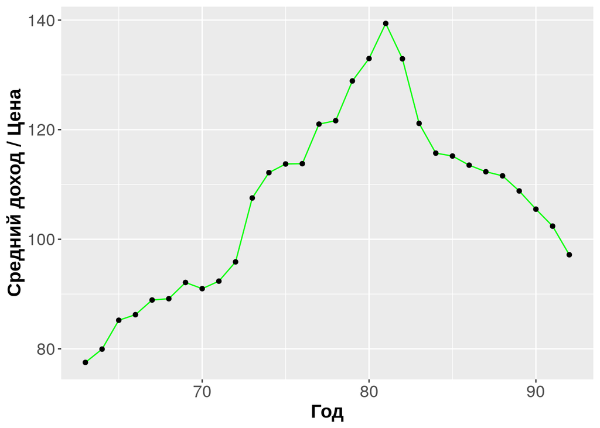

```r
ggplot(cigar3, aes(x = year, y = MeanNDI_over_Price)) +
  geom_line(color = "green") +
  geom_point() +
  xlab("Год") +
  ylab("Средний доход / Цена") +
  theme(axis.text.x = element_text(size = 14),
        axis.text.y = element_text(size = 14),
        legend.text = element_text(size = 14),
        axis.title = element_text(face = "bold", size = 16))
```